# Predicting Stock Return using ARIMA model

3. **Fitting ARIMA Model**
- **Identify potential (p, d, q) combinations**

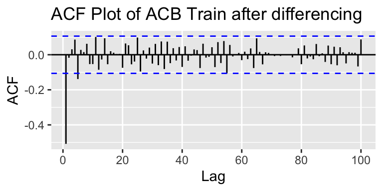

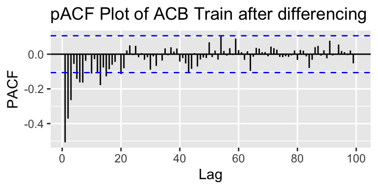

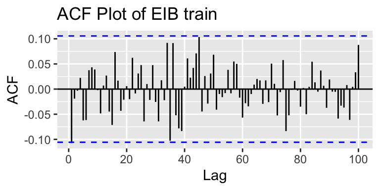

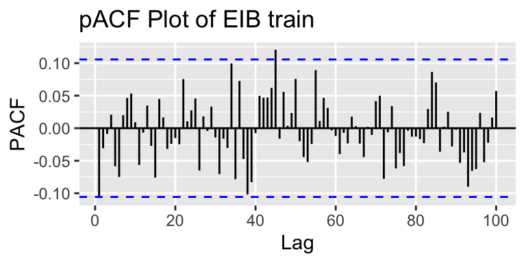

By examining the ACF plots, the terms of AR and MA of ARIMA model can be determined. Regarding ACB, the ACF’s significant lag 1 suggest a MA(1) components, while multiple lags of the pACF suggest AR(1), AR(2), and AR(3) components. By having a first order differencing, the I components of ACB’s ARIMA is d = 1. Contrastively, in the case of EIB, both the plots show no significant autocorrelation, suggesting only a constant term for the model. Nevertheless, it is better to try out the simple combinations from 1-3 for EIB’s ARIMA model.

```r
ACB_ARIMA <- auto.arima(ACB_RET_train$value, stationary = FALSE,
                        ic = c("aicc", "aic", "bic"),
                        max.p = 3, max.d = 1, max.q = 3, trace = TRUE)
```

```
##
##  Fitting models using approximations to speed things up...
##
##  ARIMA(2,1,2) with drift         : Inf
##  ARIMA(0,1,0) with drift         : -1273.419
##  ARIMA(1,1,0) with drift         : -1372.685
##  ARIMA(0,1,1) with drift         : -1495.127
##  ARIMA(0,1,0)                    : -1275.441
##  ARIMA(1,1,1) with drift         : Inf
##  ARIMA(0,1,2) with drift         : -1493.103
##  ARIMA(1,1,2) with drift         : Inf
##  ARIMA(0,1,1)                    : -1496.808
##  ARIMA(1,1,1)                    : -1495.342
##  ARIMA(0,1,2)                    : -1494.796
##  ARIMA(1,1,0)                    : -1374.714
##  ARIMA(1,1,2)                    : -1493.349
##
##  Now re-fitting the best model(s) without approximations...
##
##  ARIMA(0,1,1)                    : -1501.912
##
##  Best model: ARIMA(0,1,1)
```

```r
EIB_ARIMA <- auto.arima(EIB_RET_train$value, stationary = TRUE,
                        ic = c("aicc", "aic", "bic"),
                        max.p = 3, max.d = 0, max.q = 3,
                                  trace = TRUE)
```

```
##
##  Fitting models using approximations to speed things up...
##
##  ARIMA(2,0,2) with non-zero mean : -1408.974
##  ARIMA(0,0,0) with non-zero mean : -1413.973
##  ARIMA(1,0,0) with non-zero mean : -1414.988
##  ARIMA(0,0,1) with non-zero mean : -1416.176
##  ARIMA(0,0,0) with zero mean     : -1415.266
##  ARIMA(1,0,1) with non-zero mean : -1413.323
##  ARIMA(0,0,2) with non-zero mean : -1414.261
##  ARIMA(1,0,2) with non-zero mean : Inf
##  ARIMA(0,0,1) with zero mean     : -1417.254
##  ARIMA(1,0,1) with zero mean     : -1414.39
##  ARIMA(0,0,2) with zero mean     : -1415.313
##  ARIMA(1,0,0) with zero mean     : -1416.12
##  ARIMA(1,0,2) with zero mean     : Inf
##
##  Now re-fitting the best model(s) without approximations...
##
##  ARIMA(0,0,1) with zero mean     : -1417.243
##
##  Best model: ARIMA(0,0,1) with zero mean
```